# Procesamiento PPK reproducible de dos receptores GNSS

Base Unicore, rovers Unicore y u-blox; conversión RINEX, solución y evaluación de incertidumbre

Protocolo de procesamiento GNSS

12/10/2026

# 1 Alcance y condiciones

Este cuaderno ejecuta un **PPK estático, combinado (forward + backward)** con **GPS + GLONASS**, una **base Unicore** de coordenadas previamente determinadas por PPP (NRCan) y **dos rovers** (Unicore y u-blox). No utiliza otra base. Cada bloque puede ejecutarse independientemente, en orden, en RStudio. Los resultados se guardan en disco y no se modifican los datos brutos.

Se conserva el umbral de validación de ambigüedades **LAMBDA = 3.0**. El ajuste `l1+l2+l5` permite tres frecuencias cuando el receptor y las observaciones las aportan. El rover **u-blox F9P no mide L5**: en su caso la tercera frecuencia no añade datos. Los códigos de observación disponibles y el porcentaje FIX pueden diferir entre receptores. El procesamiento combinado usa observaciones futuras y **no representa el tiempo de convergencia en tiempo real**.

**Condiciones de ejecución:** R, RStudio, `convbin` compatible con los formatos de los registros, `rnx2rtkp` de RTKLIB demo5 compatible con la configuración, y paquetes `ggplot2`, `dplyr` y `tidyr`. Se recomienda la misma versión de RTKLIB para repetir los resultados. Los porcentajes FIX son resultados del procesamiento, no garantías de exactitud.

La estructura inicial esperada es:

```
proyecto/
├── ppp/                  # Ya contiene la solución PPP y archivos NRCan
│   └── base_unida_30s.sum
├── raw/
│   ├── base/             # Archivos .bin de la base Unicore
│   └── rover/            # Archivos originales de ambos rovers
├── ppk/                  # Inicialmente vacía
├── rinex/
│   ├── base/             # Inicialmente vacía
│   └── rover/            # Inicialmente vacía
├── scripts/              # Inicialmente vacía
└── tuberia_ppk_rovers.Rmd
```

> **Importante:** abrir el proyecto en RStudio con el directorio de trabajo situado en `proyecto/`. El archivo `.sum` de NRCan se conserva como evidencia del PPP. Las coordenadas XYZ utilizadas abajo deben verificarse contra ese informe y su época de referencia.

# 2 1. Preparación del entorno

```r
paquetes <- c("ggplot2", "dplyr", "tidyr", "knitr", "rmarkdown")

faltantes <- paquetes[
  !vapply(paquetes, requireNamespace, logical(1), quietly = TRUE)
]

if (length(faltantes)) {
  install.packages(faltantes)
}
```

```r
options(stringsAsFactors = FALSE)
library(ggplot2)
library(dplyr)
library(tidyr)

raiz <- normalizePath(getwd(), winslash = "/", mustWork = TRUE)
stopifnot(dir.exists(file.path(raiz, "raw/base")),
          dir.exists(file.path(raiz, "raw/rover")),
          dir.exists(file.path(raiz, "ppp")))

for (d in c("ppk", "ppk/unicore", "ppk/ublox", "ppk/figuras",
            "rinex", "rinex/base", "rinex/rover", "scripts")) {
  dir.create(file.path(raiz, d), recursive = TRUE, showWarnings = FALSE)
}

cat("Proyecto:", raiz, "\n")
```

```
## Proyecto: /home/jose/buffer/test-datos-yeral/gnss
```

# 3 2. Identificar entradas y ejecutables

La base se registra en archivos horarios. Para estas dos sesiones se utiliza el archivo que cubre ambos intervalos: **30 de agosto de 2026, 16:00–17:00 GPST**. Las horas y el solapamiento se comprobarán tras la conversión.

```r
# ------------------------------------------------------------
# 1. Directorios y archivos brutos
# ------------------------------------------------------------

# Una única base Unicore y dos rovers: Unicore y u-blox

dir_base  <- file.path(raiz, "raw", "base")
dir_rover <- file.path(raiz, "raw", "rover")

rover_unicore_raw <- file.path(
  dir_rover,
  "20260830-121910-unicore-nmea-data-YERAL.log"
)

rover_ublox_raw <- file.path(
  dir_rover,
  "20260830-122740-ubx-nmea-data-YERAL.ubx"
)

# Comprobar los archivos originales de los rovers
rover_raw <- c(rover_unicore_raw, rover_ublox_raw)

if (!all(file.exists(rover_raw))) {
  stop(
    "Faltan archivos originales de los rovers:\n",
    paste(rover_raw[!file.exists(rover_raw)], collapse = "\n")
  )
}

# ------------------------------------------------------------
# 2. Seleccionar archivos horarios de la base Unicore
# ------------------------------------------------------------

# Los nombres de los archivos de los rovers contienen
# la hora local de República Dominicana (UTC-4).
#
# Los archivos horarios de la base Unicore utilizan UTC.
#
# Se considera una duración máxima de 180 segundos
# para cada sesión de rover.

seleccionar_archivos_base <- function(
    rover,
    dir_base,
    duracion_max = 180,
    desfase_horas = 4
) {

  nombre <- basename(rover)
  patron <- "^([0-9]{8})-([0-9]{6})"

  if (!grepl(patron, nombre)) {
    stop("Nombre de rover no reconocido: ", nombre)
  }

  # Extraer fecha y hora del nombre
  fecha_hora <- sub(patron, "\\1\\2", nombre)

  # Interpretar la hora local como una fecha numérica
  # y aplicar explícitamente el desplazamiento UTC-4.
  inicio_local <- as.POSIXct(
    fecha_hora,
    format = "%Y%m%d%H%M%S",
    tz = "UTC"
  )

  if (is.na(inicio_local)) {
    stop("Fecha u hora inválida: ", nombre)
  }

  # Convertir la hora del nombre a UTC
  inicio_utc <- inicio_local + desfase_horas * 3600

  # Extremo superior del intervalo de observación
  fin_utc <- inicio_utc + duracion_max

  # Obtener las horas UTC que intersectan el intervalo
  hora_inicial <- floor(as.numeric(inicio_utc) / 3600) * 3600
  hora_final   <- floor(as.numeric(fin_utc) / 3600) * 3600

  horas <- as.POSIXct(
    seq(hora_inicial, hora_final, by = 3600),
    origin = "1970-01-01",
    tz = "UTC"
  )

  # Nombres de los archivos horarios de la base Unicore
  nombres_base <- paste0(
    format(horas, "%Y%m%d_%H0000", tz = "UTC"),
    "_00.bin"
  )

  archivos <- file.path(dir_base, nombres_base)

  # Comprobar que existen todos los archivos necesarios
  if (!all(file.exists(archivos))) {
    stop(
      "Faltan archivos horarios de la base Unicore:\n",
      paste(
        archivos[!file.exists(archivos)],
        collapse = "\n"
      )
    )
  }

  archivos
}

# Archivos de la MISMA base Unicore necesarios
# para cubrir la sesión de cada rover.

archivos_base_para_rover_unicore <- seleccionar_archivos_base(
  rover = rover_unicore_raw,
  dir_base = dir_base
)

archivos_base_para_rover_ublox <- seleccionar_archivos_base(
  rover = rover_ublox_raw,
  dir_base = dir_base
)

# Reunir los archivos horarios necesarios para ambas sesiones.
# Eliminar duplicados y ordenar cronológicamente.

bases_necesarias <- sort(unique(c(
  archivos_base_para_rover_unicore,
  archivos_base_para_rover_ublox
)))

cat("\nArchivos horarios de la base Unicore seleccionados:\n")
```

```
##
## Archivos horarios de la base Unicore seleccionados:
```

```r
print(basename(bases_necesarias))
```

```
## [1] "20260830_160000_00.bin"
```

```r
cat("\nBase requerida para el rover Unicore:\n")
```

```
##
## Base requerida para el rover Unicore:
```

```r
print(basename(archivos_base_para_rover_unicore))
```

```
## [1] "20260830_160000_00.bin"
```

```r
cat("\nBase requerida para el rover u-blox:\n")
```

```
##
## Base requerida para el rover u-blox:
```

```r
print(basename(archivos_base_para_rover_ublox))
```

```
## [1] "20260830_160000_00.bin"
```

```r
# ------------------------------------------------------------
# 3. Consolidar los archivos binarios de la base Unicore
# ------------------------------------------------------------

# Si ambas sesiones se encuentran dentro de la misma hora,
# se copia un único archivo.
#
# Si alguna sesión cruza una hora UTC, o los rovers
# corresponden a horas diferentes, se concatenan
# cronológicamente los archivos necesarios.
#
# Los binarios originales nunca se modifican.

unir_binarios <- function(
    archivos,
    destino,
    bloque_bytes = 1024 * 1024
) {

  if (!length(archivos)) {
    stop("No hay archivos de base para consolidar.")
  }

  archivos <- sort(unique(archivos))

  dir.create(
    dirname(destino),
    recursive = TRUE,
    showWarnings = FALSE
  )

  # Impedir que el destino sobrescriba un archivo original
  destino_normalizado <- normalizePath(
    destino,
    winslash = "/",
    mustWork = FALSE
  )

  originales <- normalizePath(
    archivos,
    winslash = "/",
    mustWork = TRUE
  )

  if (destino_normalizado %in% originales) {
    stop("El destino no puede coincidir con un archivo original.")
  }

  # Caso de un único archivo: copiar directamente
  if (length(archivos) == 1L) {

    cat("\nCopiando un único archivo de base:\n")
    cat(basename(archivos), "\n")

    if (!file.copy(
      from = archivos,
      to = destino,
      overwrite = TRUE
    )) {
      stop("No se pudo copiar el archivo de base.")
    }

  } else {

    # Caso de varios archivos: concatenación binaria
    cat("\nConcatenando", length(archivos),
        "archivos horarios de la base Unicore.\n")

    salida <- file(destino, open = "wb")
    on.exit(close(salida), add = TRUE)

    for (archivo in archivos) {

      cat("Incorporando:", basename(archivo), "\n")

      entrada <- file(archivo, open = "rb")

      tryCatch(
        {
          repeat {

            datos <- readBin(
              entrada,
              what = "raw",
              n = bloque_bytes
            )

            if (!length(datos)) break

            writeBin(datos, salida)
          }
        },
        finally = close(entrada)
      )
    }
  }

  invisible(destino)
}

# Archivo binario consolidado que utilizará convbin.
# Se conserva el nombre base_bin para compatibilidad
# con los siguientes bloques del cuaderno.

base_bin <- file.path(
  raiz,
  "rinex",
  "base",
  "base_seleccionada.bin"
)

unir_binarios(
  archivos = bases_necesarias,
  destino = base_bin
)
```

```
##
## Copiando un único archivo de base:
## 20260830_160000_00.bin
```

```r
# ------------------------------------------------------------
# 4. Verificar integridad del archivo consolidado
# ------------------------------------------------------------

bytes_esperados <- sum(
  file.info(bases_necesarias)$size
)

bytes_obtenidos <- file.info(base_bin)$size

if (is.na(bytes_obtenidos) ||
    bytes_obtenidos != bytes_esperados) {
  stop(
    "El tamaño del archivo consolidado no coincide ",
    "con la suma de los archivos originales."
  )
}

cat(
  "\nArchivo consolidado de la base Unicore:\n",
  base_bin,
  "\nTamaño:", bytes_obtenidos, "bytes\n"
)
```

```
##
## Archivo consolidado de la base Unicore:
##  /home/jose/buffer/test-datos-yeral/gnss/rinex/base/base_seleccionada.bin
## Tamaño: 23687480 bytes
```

```r
# ------------------------------------------------------------
# 5. Comprobar todas las entradas del procesamiento
# ------------------------------------------------------------

# Una base Unicore consolidada y dos rovers

entradas <- c(
  base_bin,
  rover_unicore_raw,
  rover_ublox_raw
)

if (!all(file.exists(entradas))) {
  stop(
    "Faltan archivos de entrada:\n",
    paste(
      entradas[!file.exists(entradas)],
      collapse = "\n"
    )
  )
}

# ------------------------------------------------------------
# 6. Localizar los ejecutables GNSS
# ------------------------------------------------------------

# Preferir la versión de convbin instalada en /usr/local/bin,
# si está disponible, para evitar utilizar accidentalmente
# otra compilación de RTKLIB.

convbin_preferido <- "/usr/local/bin/convbin"

if (file.exists(convbin_preferido) &&
    file.access(convbin_preferido, mode = 1) == 0) {

  convbin <- convbin_preferido

} else {

  convbin <- unname(Sys.which("convbin"))
}

rnx2rtkp <- unname(Sys.which("rnx2rtkp"))

if (!nzchar(convbin) || !nzchar(rnx2rtkp)) {
  stop(
    "No se encuentran convbin y/o rnx2rtkp ",
    "entre los ejecutables disponibles."
  )
}

cat(
  "\nHerramientas GNSS disponibles:\n",
  "convbin:   ", convbin, "\n",
  "rnx2rtkp: ", rnx2rtkp, "\n",
  sep = ""
)
```

```
##
## Herramientas GNSS disponibles:
## convbin:   /usr/local/bin/convbin
## rnx2rtkp: /usr/local/bin/rnx2rtkp
```

```r
# ------------------------------------------------------------
# 7. Inventario final de entradas
# ------------------------------------------------------------

inventario <- data.frame(
  tipo = c(
    "Base Unicore consolidada",
    "Rover Unicore",
    "Rover u-blox"
  ),
  archivo = basename(entradas),
  bytes = file.info(entradas)$size,
  ruta = entradas
)

knitr::kable(
  inventario,
  caption = "Archivos de entrada del procesamiento PPK"
)
```

Archivos de entrada del procesamiento PPK

| tipo | archivo | bytes | ruta |
| --- | --- | --- | --- |
| Base Unicore consolidada | base_seleccionada.bin | 23687480 | /home/jose/buffer/test-datos-yeral/gnss/rinex/base/base_seleccionada.bin |
| Rover Unicore | 20260830-121910-unicore-nmea-data-YERAL.log | 4310755 | /home/jose/buffer/test-datos-yeral/gnss/raw/rover/20260830-121910-unicore-nmea-data-YERAL.log |
| Rover u-blox | 20260830-122740-ubx-nmea-data-YERAL.ubx | 3553771 | /home/jose/buffer/test-datos-yeral/gnss/raw/rover/20260830-122740-ubx-nmea-data-YERAL.ubx |

La función siguiente ejecuta comandos externos y guarda tanto la salida como los mensajes de error. Un archivo de registro permite revisar cada paso.

```r
ejecutar <- function(programa, argumentos, registro) {
  dir.create(dirname(registro), recursive = TRUE, showWarnings = FALSE)
  cat("Ejecutando:", basename(programa), "\n")
  estado <- suppressWarnings(system2(programa, args = shQuote(argumentos),
                                     stdout = registro, stderr = registro))
  if (!identical(as.integer(estado), 0L)) {
    ultimas <- if (file.exists(registro)) tail(readLines(registro, warn = FALSE), 20) else ""
    stop("Comando falló (código ", estado, "):\n", paste(ultimas, collapse = "\n"))
  }
  invisible(registro)
}
```

# 4 3. Coordenadas de la base procedentes de PPP

Se emplean las coordenadas cartesianas geocéntricas **ECEF (m)** determinadas previamente mediante NRCan. Verificar el informe `ppp/base_unida_30s.sum` antes de ejecutar la solución. Estas coordenadas pertenecen a **esta base**, no a los rovers.

```r
base_xyz <- c(
  X = 2078167.0250,
  Y = -5683987.2712,
  Z = 2006702.5967
)
print(base_xyz)
```

```
##        X        Y        Z
##  2078167 -5683987  2006703
```

```r
cat("Informe PPP disponible:", file.exists(file.path(raiz, "ppp/base_unida_30s.sum")), "\n")
```

```
## Informe PPP disponible: TRUE
```

**Control geodésico:** registrar el marco de referencia, época, tipo de antena y altura de referencia utilizados por NRCan. Las coordenadas ECEF deben corresponder al punto físico de referencia de la antena/base; una confusión entre ARP y centro de fase produce un sesgo vertical.

# 5 4. Conversión de datos brutos a RINEX

Se ejecutan las conversiones apropiadas para cada registro, conservando los archivos originales. Las observaciones y la navegación de un mismo registro pueden recuperarse en pasos separados.

## 5.1 4.1 Base Unicore

```r
base_obs <- file.path(raiz, "rinex/base/base_unicore.obs")
base_nav <- file.path(raiz, "rinex/base/base_unicore.nav")
ejecutar(convbin,
        c("-r", "unicore", "-v", "3.04", "-o", base_obs, "-n", base_nav, base_bin),
        file.path(raiz, "rinex/base/conversion.log"))
```

```
## Ejecutando: convbin
```

```r
stopifnot(file.exists(base_obs), file.exists(base_nav))
```

## 5.2 4.2 Rover Unicore: observaciones y navegación

```r
uni_obs <- file.path(raiz, "rinex/rover/rover_unicore.obs")
uni_nav <- file.path(raiz, "rinex/rover/rover_unicore.nav")

ejecutar(convbin,
        c("-r", "nov", "-v", "3.04", "-o", uni_obs,
          "-n", file.path(raiz, "rinex/rover/nav_temporal_unicore.nav"),
          rover_unicore_raw),
        file.path(raiz, "rinex/rover/conversion_obs_unicore.log"))
```

```
## Ejecutando: convbin
```

```r
ejecutar(convbin,
        c("-r", "unicore", "-v", "3.04",
          "-o", file.path(raiz, "rinex/rover/obs_temporal_unicore.obs"),
          "-n", uni_nav, rover_unicore_raw),
        file.path(raiz, "rinex/rover/conversion_nav_unicore.log"))
```

```
## Ejecutando: convbin
```

```r
stopifnot(file.exists(uni_obs), file.exists(uni_nav))
```

Los nombres de formato en los comandos anteriores son **parámetros técnicos del conversor** y no cambian la marca ni el tipo del receptor utilizado. Los archivos temporales solo se generan si el conversor encuentra datos de ese tipo.

## 5.3 4.3 Rover u-blox

```r
ubx_obs <- file.path(raiz, "rinex/rover/rover_ublox.obs")
ubx_nav <- file.path(raiz, "rinex/rover/rover_ublox.nav")
ejecutar(convbin,
        c("-r", "ubx", "-v", "3.04", "-o", ubx_obs, "-n", ubx_nav,
          rover_ublox_raw),
        file.path(raiz, "rinex/rover/conversion_ublox.log"))
```

```
## Ejecutando: convbin
```

```r
stopifnot(file.exists(ubx_obs), file.exists(ubx_nav))
```

## 5.4 4.4 Control de épocas y señales

```r
resumen_rinex <- function(archivo) {
  con <- file(archivo, open = "rt")
  on.exit(close(con))
  cab <- character()
  repeat {
    linea <- readLines(con, n = 1L, warn = FALSE)
    if (!length(linea)) stop("Cabecera incompleta: ", archivo)
    cab <- c(cab, linea)
    if (grepl("END OF HEADER", linea, fixed = TRUE)) break
  }
  # Conteo en flujo, sin cargar el RINEX grande completo en memoria
  epocas <- 0L
  repeat {
    bloque <- readLines(con, n = 10000L, warn = FALSE)
    if (!length(bloque)) break
    epocas <- epocas + sum(startsWith(bloque, ">"))
  }
  list(epocas = epocas,
       tiempos = grep("TIME OF (FIRST|LAST) OBS", cab, value = TRUE),
       tipos = grep("SYS / # / OBS TYPES", cab, value = TRUE))
}

for (archivo in c(base_obs, uni_obs, ubx_obs)) {
  a <- resumen_rinex(archivo)
  cat("\n", basename(archivo), "— épocas:", a$epocas, "\n")
  cat(paste(a$tiempos, collapse = "\n"), "\n")
  cat(paste(a$tipos, collapse = "\n"), "\n")
}
```

```
##
##  base_unicore.obs — épocas: 3600
##   2026    08    30    16    00   00.0000000     GPS         TIME OF FIRST OBS
##   2026    08    30    16    59   59.0000000     GPS         TIME OF LAST OBS
## G    8 C1C L1C C1L L1L C2L L2L C5Q L5Q                      SYS / # / OBS TYPES
## R    6 C1C L1C C2C L2C C3Q L3Q                              SYS / # / OBS TYPES
## E    8 C1C L1C C7Q L7Q C5Q L5Q C6C L6C                      SYS / # / OBS TYPES
## C   10 C2I L2I C7P L7P C5P L5P C6I L6I C1P L1P              SYS / # / OBS TYPES
##
##  rover_unicore.obs — épocas: 635
##   2026    08    30    16    19   28.6000000     GPS         TIME OF FIRST OBS
##   2026    08    30    16    21   35.4000000     GPS         TIME OF LAST OBS
## G    8 C1C L1C C2W L2W C2S L2S C5Q L5Q                      SYS / # / OBS TYPES
## R    4 C1C L1C C2P L2P                                      SYS / # / OBS TYPES
## E    6 C1C L1C C7Q L7Q C5Q L5Q                              SYS / # / OBS TYPES
## C    2 C2I L2I                                              SYS / # / OBS TYPES
##
##  rover_ublox.obs — épocas: 632
##   2026    08    30    16    27   58.2050000     GPS         TIME OF FIRST OBS
##   2026    08    30    16    30   04.4050000     GPS         TIME OF LAST OBS
## G    4 C1C L1C C2X L2X                                      SYS / # / OBS TYPES
## R    4 C1C L1C C2C L2C                                      SYS / # / OBS TYPES
## E    4 C1X L1X C7X L7X                                      SYS / # / OBS TYPES
## S    2 C1C L1C                                              SYS / # / OBS TYPES
## C    2 C2I L2I                                              SYS / # / OBS TYPES
```

Para estos registros se esperan aproximadamente **3600 épocas de base**, **635 épocas del rover Unicore** y **632 épocas del rover u-blox**. Ambos rovers se registraron en momentos distintos, aunque dentro del intervalo de la base. Si las fechas no se solapan, no ejecutar el PPK.

# 6 5. Crear las configuraciones RTKLIB en `scripts/`

Se generan **dos archivos `.conf` desde R**, uno para cada rover, sin depender de configuraciones previas. Ambos utilizan los mismos parámetros de posicionamiento: estático, combinado, GPS + GLONASS, frecuencia configurada como `l1+l2+l5`, umbral LAMBDA 3.0 y coordenadas PPP de la base. GLONASS se incorpora a la estimación, pero la fijación específica de sus ambigüedades se mantiene desactivada (`pos2-gloarmode=off`), reproduciendo el ajuste de referencia. El receptor u-blox puede aprovechar solamente las frecuencias que realmente registró.

```r
crear_conf <- function(
    destino, xyz,
    navsys = 5L,
    frecuencias = "l1+l2+l5",
    ratio = 3,
    elevacion_ar = 15,
    arlockcnt = 0,
    minfixsats = 4
) {

  opciones <- c(
    # Posicionamiento
    "pos1-posmode       =static",
    paste0("pos1-frequency     =", frecuencias),
    "pos1-soltype       =combined",
    "pos1-elmask        =15",
    "pos1-snrmask_r     =off",
    "pos1-snrmask_b     =off",
    "pos1-dynamics      =off",
    "pos1-tidecorr      =off",
    "pos1-ionoopt       =brdc",
    "pos1-tropopt       =saas",
    "pos1-sateph        =brdc",
    "pos1-exclsats      =",
    paste0("pos1-navsys        =", navsys),

    # Resolución de ambigüedades
    "pos2-armode        =continuous",
    "pos2-gloarmode     =off",
    "pos2-bdsarmode     =off",
    "pos2-arfilter      =on",

    sprintf("pos2-arthres       =%s", ratio),
    sprintf("pos2-arthresmin    =%s", ratio),
    sprintf("pos2-arthresmax    =%s", ratio),
    "pos2-arthres1      =0.04",

    sprintf("pos2-arlockcnt     =%d", arlockcnt),
    sprintf("pos2-minfixsats    =%d", minfixsats),
    "pos2-mindropsats   =10",
    sprintf("pos2-arelmask      =%s", elevacion_ar),
    "pos2-arminfix      =10",
    "pos2-armaxiter     =1",

    # Rechazo de observaciones
    "pos2-rejphase      =2",
    "pos2-rejcode       =10",

    # Modelo estocástico
    "stats-eratio1      =300",
    "stats-eratio2      =300",
    "stats-eratio5      =300",
    "stats-errphase     =0.005",
    "stats-errphaseel   =0.005",
    "stats-errsnr       =0",

    # Salida
    "out-solformat      =llh",
    "out-outhead        =on",
    "out-outopt         =on",
    "out-timesys        =gpst",
    "out-timeform       =hms",
    "out-degform        =deg",
    "out-fieldsep       =",
    "out-height         =ellipsoidal",
    "out-solstatic      =all",
    "out-outstat        =residual",

    # Coordenadas de base
    "ant1-postype       =single",
    "ant2-postype       =xyz",
    sprintf("ant2-pos1          =%.4f", xyz[["X"]]),
    sprintf("ant2-pos2          =%.4f", xyz[["Y"]]),
    sprintf("ant2-pos3          =%.4f", xyz[["Z"]])
  )

  writeLines(opciones, destino)
  destino
}


conf_uni <- crear_conf(file.path(raiz, "scripts/ppk_unicore.conf"), base_xyz)
conf_ubx <- crear_conf(file.path(raiz, "scripts/ppk_ublox.conf"), base_xyz)
cat("Configuraciones creadas:\n", conf_uni, "\n", conf_ubx, "\n")
```

```
## Configuraciones creadas:
##  /home/jose/buffer/test-datos-yeral/gnss/scripts/ppk_unicore.conf
##  /home/jose/buffer/test-datos-yeral/gnss/scripts/ppk_ublox.conf
```

```r
cat(paste(grep("pos1-(frequency|soltype|navsys)|pos2-(gloarmode|arthres)",
               readLines(conf_uni), value = TRUE), collapse = "\n"))
```

```
## pos1-frequency     =l1+l2+l5
## pos1-soltype       =combined
## pos1-navsys        =5
## pos2-gloarmode     =off
## pos2-arthres       =3
## pos2-arthresmin    =3
## pos2-arthresmax    =3
## pos2-arthres1      =0.04
```

> **Compatibilidad:** RTKLIB demo5 debe reconocer `l1+l2+l5` y compilarse con capacidad para tres frecuencias. Revisar la cabecera del `.pos` después de ejecutar. Si el binario solo admite dos frecuencias, el resultado no debe etiquetarse como triple frecuencia. No se modifica el umbral LAMBDA para forzar FIX.

# 7 6. Calcular las soluciones PPK

Se utiliza la misma base y los archivos de navegación disponibles para cada rover. Los resultados se guardan en directorios independientes.

## 7.1 6.1 Rover Unicore

```r
pos_uni <- file.path(raiz, "ppk/unicore/solucion.pos")
ejecutar(rnx2rtkp,
        c("-k", conf_uni, "-o", pos_uni,
          uni_obs, base_obs, uni_nav, base_nav),
        file.path(raiz, "ppk/unicore/procesamiento.log"))
```

```
## Ejecutando: rnx2rtkp
```

```r
stopifnot(file.exists(pos_uni))
cat(paste(head(readLines(pos_uni, n = 40), 30), collapse = "\n"))
```

```
## % program   : RTKLIB ver.EX 2.5.1
## % inp file  : /home/jose/buffer/test-datos-yeral/gnss/rinex/rover/rover_unicore.obs
## % inp file  : /home/jose/buffer/test-datos-yeral/gnss/rinex/base/base_unicore.obs
## % inp file  : /home/jose/buffer/test-datos-yeral/gnss/rinex/rover/rover_unicore.nav
## % inp file  : /home/jose/buffer/test-datos-yeral/gnss/rinex/base/base_unicore.nav
## % obs start : 2026/08/30 16:19:28.6 GPST (week2434  58768.6s)
## % obs end   : 2026/08/30 16:21:35.4 GPST (week2434  58895.4s)
## % pos mode  : Static
## % freqs     : L1+L2/E5b+L5
## % solution  : Combined-Phase Reset
## % elev mask : 15.0 deg
## % dynamics  : off
## % tidecorr  :
## % ionos opt : Broadcast
## % tropo opt : Saastamoinen
## % ephemeris : Broadcast
## % navi sys  : GPS GLONASS
## % amb res   : Continuous
## % amb glo   : OFF
## % val thres : 3.0
## % antenna1  :                       ( 0.0000  0.0000  0.0000)
## % antenna2  :                       ( 0.0000  0.0000  0.0000)
## % ref pos   :  18.459649417  -69.916687223   -11.5840
## %
## % (lat/lon/height=WGS84/ellipsoidal,Q=1:fix,2:float,3:sbas,4:dgps,5:single,6:ppp,ns=# of satellites)
## %  GPST                  latitude(deg) longitude(deg)  height(m)   Q  ns   sdn(m)   sde(m)   sdu(m)  sdne(m)  sdeu(m)  sdun(m) age(s)  ratio
## 2026/08/30 16:19:28.600   18.461990060  -69.915350921   -19.1424   1  13   0.0003   0.0004   0.0007   0.0002   0.0003   0.0002  -0.40    4.7
## 2026/08/30 16:19:28.800   18.461990060  -69.915350921   -19.1424   1  13   0.0003   0.0004   0.0007   0.0002   0.0003   0.0002  -0.20    4.7
## 2026/08/30 16:19:29.000   18.461990060  -69.915350921   -19.1424   1  13   0.0003   0.0004   0.0007   0.0002   0.0003   0.0002   0.00    4.6
## 2026/08/30 16:19:29.200   18.461990060  -69.915350921   -19.1425   1  13   0.0003   0.0004   0.0007   0.0002   0.0003   0.0002   0.20    4.5
```

## 7.2 6.2 Rover u-blox

```r
pos_ubx <- file.path(raiz, "ppk/ublox/solucion.pos")
ejecutar(rnx2rtkp,
        c("-k", conf_ubx, "-o", pos_ubx,
          ubx_obs, base_obs, ubx_nav, base_nav),
        file.path(raiz, "ppk/ublox/procesamiento.log"))
```

```
## Ejecutando: rnx2rtkp
```

```r
stopifnot(file.exists(pos_ubx))
cat(paste(head(readLines(pos_ubx, n = 40), 30), collapse = "\n"))
```

```
## % program   : RTKLIB ver.EX 2.5.1
## % inp file  : /home/jose/buffer/test-datos-yeral/gnss/rinex/rover/rover_ublox.obs
## % inp file  : /home/jose/buffer/test-datos-yeral/gnss/rinex/base/base_unicore.obs
## % inp file  : /home/jose/buffer/test-datos-yeral/gnss/rinex/rover/rover_ublox.nav
## % inp file  : /home/jose/buffer/test-datos-yeral/gnss/rinex/base/base_unicore.nav
## % obs start : 2026/08/30 16:27:58.2 GPST (week2434  59278.2s)
## % obs end   : 2026/08/30 16:30:04.4 GPST (week2434  59404.4s)
## % pos mode  : Static
## % freqs     : L1+L2/E5b+L5
## % solution  : Combined-Phase Reset
## % elev mask : 15.0 deg
## % dynamics  : off
## % tidecorr  :
## % ionos opt : Broadcast
## % tropo opt : Saastamoinen
## % ephemeris : Broadcast
## % navi sys  : GPS GLONASS
## % amb res   : Continuous
## % amb glo   : OFF
## % val thres : 3.0
## % antenna1  :                       ( 0.0000  0.0000  0.0000)
## % antenna2  :                       ( 0.0000  0.0000  0.0000)
## % ref pos   :  18.459649417  -69.916687223   -11.5840
## %
## % (lat/lon/height=WGS84/ellipsoidal,Q=1:fix,2:float,3:sbas,4:dgps,5:single,6:ppp,ns=# of satellites)
## %  GPST                  latitude(deg) longitude(deg)  height(m)   Q  ns   sdn(m)   sde(m)   sdu(m)  sdne(m)  sdeu(m)  sdun(m) age(s)  ratio
## 2026/08/30 16:27:58.200   18.461990013  -69.915350840   -19.1534   1  13   0.0003   0.0008   0.0009   0.0002  -0.0004  -0.0002   0.20    7.8
## 2026/08/30 16:27:58.400   18.461990014  -69.915350840   -19.1531   1  14   0.0003   0.0007   0.0009   0.0002  -0.0004  -0.0002   0.41    4.0
## 2026/08/30 16:27:58.600   18.461990014  -69.915350842   -19.1531   1  13   0.0003   0.0007   0.0009   0.0002  -0.0004  -0.0002  -0.40    3.8
## 2026/08/30 16:27:58.800   18.461990014  -69.915350840   -19.1531   1  13   0.0003   0.0007   0.0009   0.0002  -0.0004  -0.0002  -0.19    3.7
```

Los dos rovers se observaron en intervalos **no simultáneos**; sus diferencias no pueden atribuirse únicamente a la marca del receptor. La cobertura parcial del dosel, la geometría y la calidad de señal pueden afectar de manera distinta a cada sesión.

# 8 7. Leer y evaluar las soluciones

En la salida estándar LLH de RTKLIB, las columnas son fecha, hora GPST, latitud, longitud, altura elipsoidal, calidad `Q`, número de satélites `ns`, desviaciones estándar norte/este/vertical, covarianzas, edad y ratio. Las incertidumbres estimadas por RTKLIB son **formales**, no errores medidos frente a una verdad terreno.

```r
leer_pos <- function(archivo, nombre) {
  lineas <- readLines(archivo, warn = FALSE)
  lineas <- lineas[nzchar(trimws(lineas)) & !startsWith(trimws(lineas), "%")]
  if (!length(lineas)) stop("Sin soluciones: ", archivo)
  x <- read.table(text = paste(lineas, collapse = "\n"), header = FALSE,
                  fill = TRUE, stringsAsFactors = FALSE)
  if (ncol(x) < 15L) stop("Formato inesperado en ", archivo, ": ", ncol(x), " columnas")
  x <- x[, 1:15]
  names(x) <- c("fecha", "hora", "lat", "lon", "h", "Q", "ns",
                "sdn", "sde", "sdu", "sdne", "sdeu", "sdun", "age", "ratio")
  numericas <- setdiff(names(x), c("fecha", "hora"))
  x[numericas] <- lapply(x[numericas], as.numeric)
  x$instante <- as.POSIXct(paste(x$fecha, x$hora),
                          format = "%Y/%m/%d %H:%M:%OS", tz = "UTC")
  x$segundo <- as.numeric(difftime(x$instante, min(x$instante), units = "secs"))
  x$receptor <- nombre
  x$calidad <- factor(ifelse(x$Q == 1, "FIX", ifelse(x$Q == 2, "FLOAT", "Otra")),
                      levels = c("FIX", "FLOAT", "Otra"))
  x
}

soluciones <- bind_rows(
  leer_pos(pos_uni, "Unicore"),
  leer_pos(pos_ubx, "u-blox")
)

resumen <- soluciones |>
  group_by(receptor) |>
  summarise(
    epocas = n(),
    fix = sum(Q == 1, na.rm = TRUE),
    float = sum(Q == 2, na.rm = TRUE),
    porcentaje_fix = 100 * mean(Q == 1, na.rm = TRUE),
    ratio_mediano = median(ratio[is.finite(ratio)], na.rm = TRUE),
    .groups = "drop"
  )
knitr::kable(resumen, digits = 2, caption = "Resumen de calidad de las soluciones PPK")
```

Resumen de calidad de las soluciones PPK

| receptor | epocas | fix | float | porcentaje_fix | ratio_mediano |
| --- | --- | --- | --- | --- | --- |
| Unicore | 635 | 635 | 0 | 100.00 | 5.8 |
| u-blox | 632 | 441 | 191 | 69.78 | 3.2 |

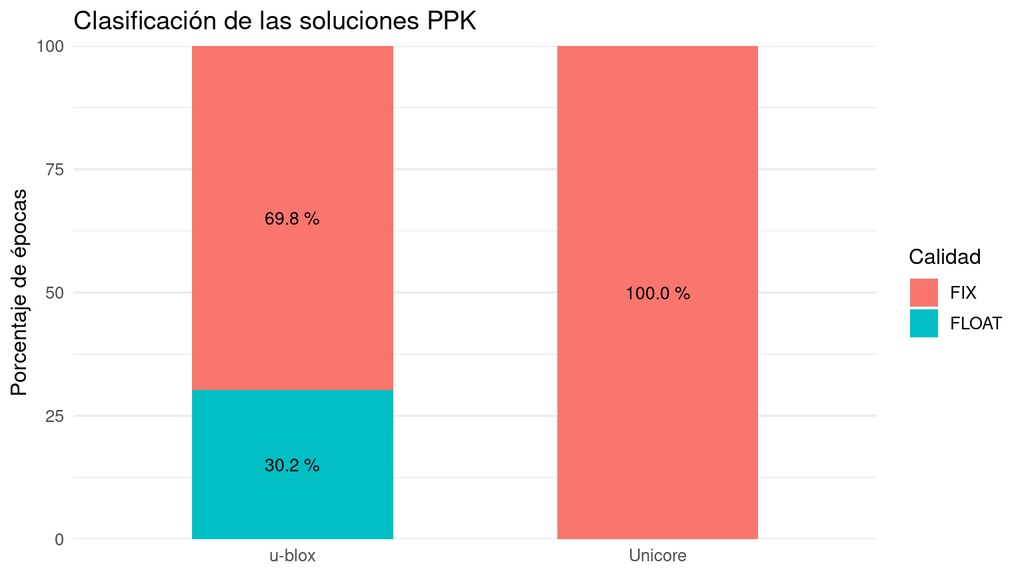

```r
calidades <- soluciones |>
  count(receptor, calidad) |>
  group_by(receptor) |>
  mutate(porcentaje = 100 * n / sum(n)) |>
  ungroup()

ggplot(calidades, aes(receptor, porcentaje, fill = calidad)) +
  geom_col(width = 0.55) +
  geom_text(aes(label = sprintf("%.1f %%", porcentaje)),
            position = position_stack(vjust = 0.5), size = 3.5) +
  scale_y_continuous(limits = c(0, 100), expand = expansion(mult = c(0, 0))) +
  labs(x = NULL, y = "Porcentaje de épocas", fill = "Calidad",
       title = "Clasificación de las soluciones PPK") +
  theme_minimal(base_size = 12)
```

# 9 8. Coordenadas locales y barras de error

Para comparar las posiciones en metros, se transforman las coordenadas geodésicas WGS84/GRS80 de las soluciones a un sistema local **este–norte–arriba (ENU)**, centrado en la **mediana de las posiciones FIX de cada rover**. Esto permite analizar dispersión sin confundirla con la distancia entre puntos levantados. Las barras de error se calculan a partir de las desviaciones estándar formales de RTKLIB; se muestran como **±1 desviación estándar**, no como intervalos de confianza del 95 %.

```r
a_wgs <- 6378137.0
f_wgs <- 1 / 298.257223563
e2_wgs <- f_wgs * (2 - f_wgs)

a_ecef <- function(lat, lon, h) {
  phi <- lat * pi / 180
  lam <- lon * pi / 180
  N <- a_wgs / sqrt(1 - e2_wgs * sin(phi)^2)
  cbind(
    X = (N + h) * cos(phi) * cos(lam),
    Y = (N + h) * cos(phi) * sin(lam),
    Z = (N * (1 - e2_wgs) + h) * sin(phi)
  )
}

calcular_enu <- function(datos) {
  fijos <- datos[datos$Q == 1 & complete.cases(datos[, c("lat", "lon", "h")]), ]
  if (nrow(fijos) < 2) {
    datos$E <- datos$N <- datos$U <- NA_real_
    return(datos)
  }
  lat0 <- median(fijos$lat)
  lon0 <- median(fijos$lon)
  h0 <- median(fijos$h)
  p0 <- as.numeric(a_ecef(lat0, lon0, h0))
  xyz <- a_ecef(datos$lat, datos$lon, datos$h)
  delta <- sweep(xyz, 2, p0, "-")
  phi <- lat0 * pi / 180
  lam <- lon0 * pi / 180
  datos$E <- -sin(lam) * delta[, 1] + cos(lam) * delta[, 2]
  datos$N <- -sin(phi)*cos(lam)*delta[, 1] - sin(phi)*sin(lam)*delta[, 2] + cos(phi)*delta[, 3]
  datos$U <- cos(phi)*cos(lam)*delta[, 1] + cos(phi)*sin(lam)*delta[, 2] + sin(phi)*delta[, 3]
  datos
}

soluciones_enu <- bind_rows(lapply(split(soluciones, soluciones$receptor), calcular_enu))
```

## 9.1 8.1 Dispersión horizontal de épocas FIX, con barras de error

Se dibuja una barra horizontal `±sde` y una vertical `±sdn` por época FIX. Las barras describen la incertidumbre **formal por época**, no el error respecto a una coordenada de control. Si hay cientos de puntos, la superposición es esperable; el gráfico es interactuable mediante zoom en el HTML del navegador, o se puede exportar en mayor resolución.

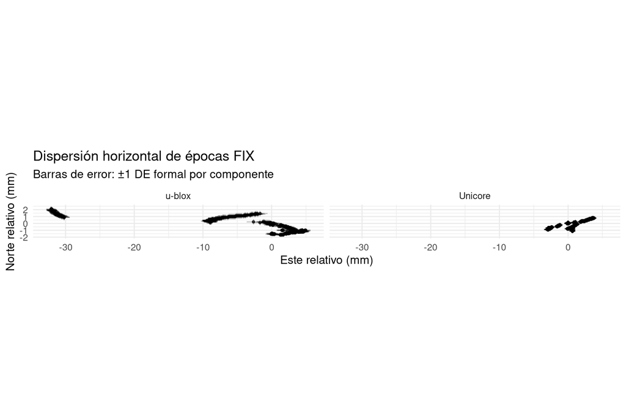

```r
fix_enu <- soluciones_enu |> filter(Q == 1, is.finite(E), is.finite(N))

if (nrow(fix_enu) > 0) {
  g_horizontal <- ggplot(fix_enu, aes(E * 1000, N * 1000)) +
    geom_segment(aes(x = (E-sde)*1000, xend = (E+sde)*1000,
                     y = N*1000, yend = N*1000), alpha = 0.22) +
    geom_segment(aes(x = E*1000, xend = E*1000,
                     y = (N-sdn)*1000, yend = (N+sdn)*1000), alpha = 0.22) +
    geom_point(size = 0.9, alpha = 0.7) +
    facet_wrap(~receptor) +
    coord_equal() +
    labs(x = "Este relativo (mm)", y = "Norte relativo (mm)",
         title = "Dispersión horizontal de épocas FIX",
         subtitle = "Barras de error: ±1 DE formal por componente") +
    theme_minimal(base_size = 12)
  print(g_horizontal)
  ggsave(file.path(raiz, "ppk/figuras/dispersión_horizontal.png"),
         g_horizontal, width = 10, height = 6, dpi = 200)
} else {
  cat("No hay épocas FIX para representar.\n")
}
```

## 9.2 8.2 Componente vertical y barras de error

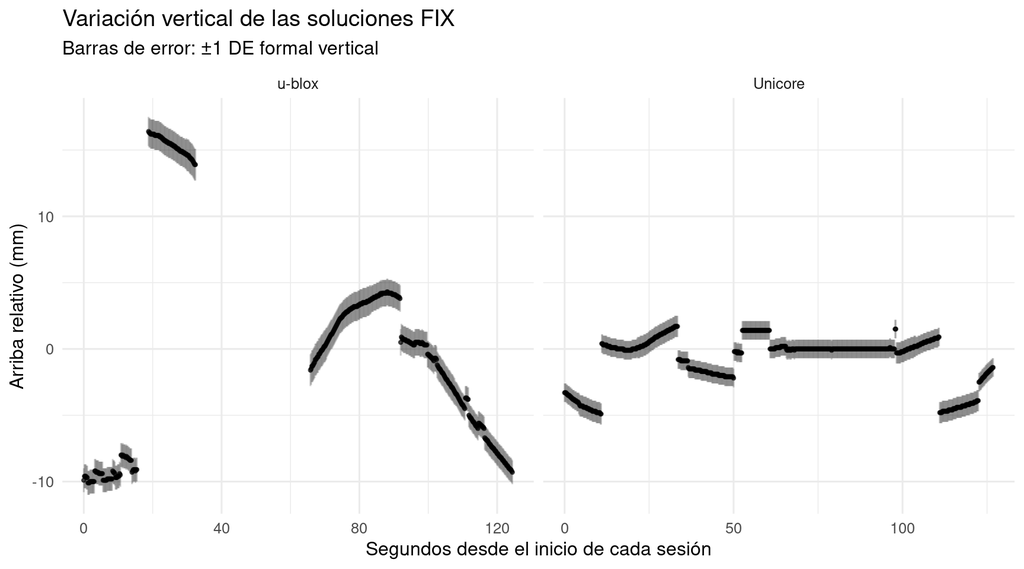

```r
if (nrow(fix_enu) > 0) {
  g_vertical <- ggplot(fix_enu, aes(segundo, U * 1000)) +
    geom_errorbar(aes(ymin = (U-sdu)*1000, ymax = (U+sdu)*1000),
                  width = 0, alpha = 0.2) +
    geom_point(size = 0.8, alpha = 0.65) +
    facet_wrap(~receptor, scales = "free_x") +
    labs(x = "Segundos desde el inicio de cada sesión", y = "Arriba relativo (mm)",
         title = "Variación vertical de las soluciones FIX",
         subtitle = "Barras de error: ±1 DE formal vertical") +
    theme_minimal(base_size = 12)
  print(g_vertical)
  ggsave(file.path(raiz, "ppk/figuras/variación_vertical.png"),
         g_vertical, width = 10, height = 5, dpi = 200)
}
```

## 9.3 8.3 Dispersión observada y precisión formal

La **dispersión observada** se calcula como desviación estándar de las posiciones FIX en ENU. Se presenta separadamente de la **incertidumbre formal mediana** (`sdn`, `sde`, `sdu`) estimada por RTKLIB. No son magnitudes equivalentes y ninguna, por sí sola, estima el sesgo absoluto.

```r
comparacion <- fix_enu |>
  group_by(receptor) |>
  summarise(
    n_fix = n(),
    sd_E_mm = sd(E, na.rm = TRUE) * 1000,
    sd_N_mm = sd(N, na.rm = TRUE) * 1000,
    sd_U_mm = sd(U, na.rm = TRUE) * 1000,
    formal_E_mm = median(sde, na.rm = TRUE) * 1000,
    formal_N_mm = median(sdn, na.rm = TRUE) * 1000,
    formal_U_mm = median(sdu, na.rm = TRUE) * 1000,
    .groups = "drop"
  )
knitr::kable(comparacion, digits = 3,
             caption = "Dispersión temporal de FIX e incertidumbre formal mediana (mm)")
```

Dispersión temporal de FIX e incertidumbre formal mediana (mm)

| receptor | n_fix | sd_E_mm | sd_N_mm | sd_U_mm | formal_E_mm | formal_N_mm | formal_U_mm |
| --- | --- | --- | --- | --- | --- | --- | --- |
| Unicore | 635 | 1.744 | 0.515 | 1.846 | 0.4 | 0.3 | 0.7 |
| u-blox | 441 | 11.931 | 1.071 | 7.986 | 0.8 | 0.3 | 1.0 |

# 10 9. Evolución de la calidad y el ratio LAMBDA

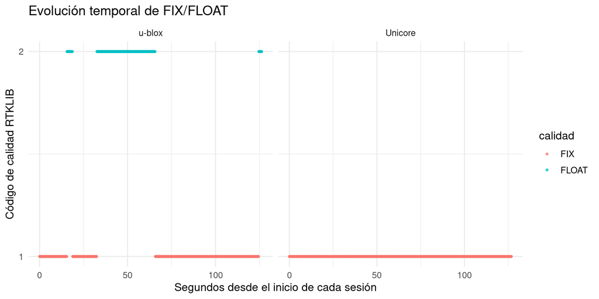

```r
ggplot(soluciones, aes(segundo, Q, color = calidad)) +
  geom_point(alpha = 0.7, size = 0.8) +
  facet_wrap(~receptor, scales = "free_x") +
  scale_y_continuous(breaks = c(1, 2, 5)) +
  labs(x = "Segundos desde el inicio de cada sesión", y = "Código de calidad RTKLIB",
       title = "Evolución temporal de FIX/FLOAT") +
  theme_minimal(base_size = 12)
```

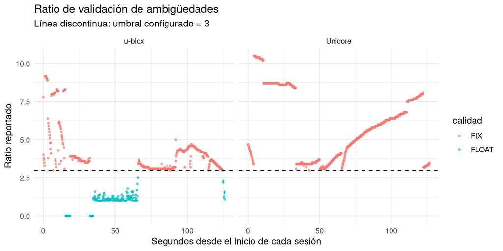

```r
ggplot(soluciones, aes(segundo, ratio, color = calidad)) +
  geom_point(alpha = 0.65, size = 0.8) +
  geom_hline(yintercept = 3, linetype = "dashed") +
  facet_wrap(~receptor, scales = "free_x") +
  labs(x = "Segundos desde el inicio de cada sesión", y = "Ratio reportado",
       title = "Ratio de validación de ambigüedades",
       subtitle = "Línea discontinua: umbral configurado = 3") +
  theme_minimal(base_size = 12)
```

# 11 10. Guardar resultados y reproducibilidad

```r
write.csv(resumen, file.path(raiz, "ppk/resumen_calidad.csv"), row.names = FALSE)
write.csv(comparacion, file.path(raiz, "ppk/resumen_dispersion.csv"), row.names = FALSE)
write.csv(soluciones_enu, file.path(raiz, "ppk/soluciones_enu.csv"), row.names = FALSE)

archivos_control <- c(entradas, conf_uni, conf_ubx)
hashes <- tools::md5sum(archivos_control)
write.csv(data.frame(archivo = names(hashes), md5 = unname(hashes)),
          file.path(raiz, "ppk/huellas_archivos.csv"), row.names = FALSE)
writeLines(capture.output(sessionInfo()), file.path(raiz, "ppk/sesion_R.txt"))
cat("Resultados guardados en ppk/.\n")
```

```
## Resultados guardados en ppk/.
```

# 12 11. Interpretación y límites

1. **FIX** significa que RTKLIB aceptó una solución de ambigüedades enteras según los criterios configurados. Un porcentaje elevado de FIX no valida por sí solo la exactitud absoluta.
2. **Combined** aprovecha toda la sesión en ambos sentidos temporales. Es adecuado para posprocesamiento, pero no representa una solución causal disponible en tiempo real.
3. **Triple frecuencia:** el rover Unicore dispone de señales GPS L5 cuando las observa; el rover u-blox F9P no. El encabezado RINEX determina las señales realmente disponibles.
4. **GLONASS:** la configuración incorpora GLONASS (`pos1-navsys=5`) y mantiene desactivada su fijación específica de ambigüedades (`pos2-gloarmode=off`). Esto evita atribuir erróneamente una mejora de FIX a la fijación de ambigüedades GLONASS.
5. **Dosel y sesiones no simultáneas:** las diferencias entre rovers pueden depender del entorno, de la geometría y de las señales observadas, no solo de la marca.
6. **Barras de error:** representan incertidumbres formales por época, no intervalos de confianza calibrados ni errores frente a una referencia independiente. La dispersión entre soluciones combinadas está correlacionada y puede ser muy pequeña.
7. **Comparación de coordenadas:** los gráficos ENU están centrados separadamente para cada rover. Si se quiere estimar la diferencia física entre puntos, se debe usar una referencia ENU común y conocer si ambos ocuparon exactamente el mismo punto y la misma altura de antena.
8. **Control externo:** cuando sea posible, contrastar el resultado con un punto de coordenadas conocidas o una sesión independiente.

# 13 12. Compilar a HTML

En RStudio, utilizar **Knit → Knit to HTML**. También se puede ejecutar desde la consola de R, estando en la raíz del proyecto:

```r
rmarkdown::render("tuberia_ppk_rovers.Rmd", output_format = "html_document")
```

**Nota:** al compilar, los bloques se ejecutan desde el comienzo y pueden volver a generar archivos. Para trabajar paso a paso, ejecutar cada bloque en orden y compilar al final. Para evitar reprocesar datos al compilar, se pueden cambiar temporalmente a `eval=FALSE` los bloques de conversión y PPK una vez creados sus productos.